# Relatório Mensal do IPCA

Inflação ao Consumidor — Brasil

## Introdução

Este relatório apresenta uma leitura analítica do Índice Nacional de Preços ao Consumidor Amplo (IPCA) com base nos dados mais recentes divulgados pelo IBGE. Todas as séries são obtidas diretamente das fontes oficiais — Banco Central do Brasil e SIDRA/IBGE — e atualizadas automaticamente a cada nova publicação.

Em abril de 2026, o IPCA registrou variação de **0.67%** no mês. No acumulado do ano, o índice soma **2.60%**, enquanto o acumulado em 12 meses alcança **4.39%** — dentro da banda de tolerância definida pelo Conselho Monetário Nacional, cuja meta para o ano é de **3.0%**.

O relatório está organizado em quatro blocos analíticos: variação mensal recente, trajetória acumulada em 12 meses frente à meta, padrão sazonal histórico e decomposição por grupos de despesa. A leitura conjunta dessas dimensões permite identificar tendências de curto prazo, pressões pontuais e a dinâmica subjacente da inflação ao consumidor no Brasil.

## Panorama Mensal

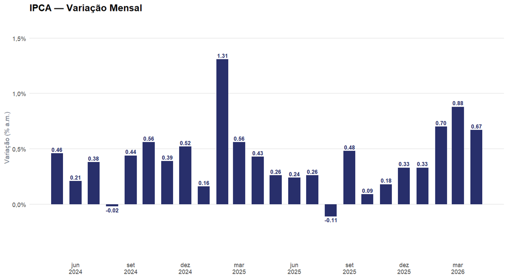

A variação mensal do IPCA nos últimos 24 meses evidencia o ritmo corrente da inflação ao consumidor. Em abril de 2026, a variação de 0.67% reflete pressões sobre o orçamento das famílias brasileiras. A leitura mês a mês é volátil por natureza — influenciada por fatores sazonais, choques de oferta e reajustes de preços administrados — razão pela qual a análise acumulada complementa o panorama.

A comparação visual das barras permite identificar meses com acelerações ou desacelerações pontuais, bem como eventuais deflações. O período recente aponta para aceleração em relação à média dos últimos 12 meses, sinal que o acumulado em 12 meses confirmará ou relativizará na seção seguinte.

## Acumulado em 12 Meses

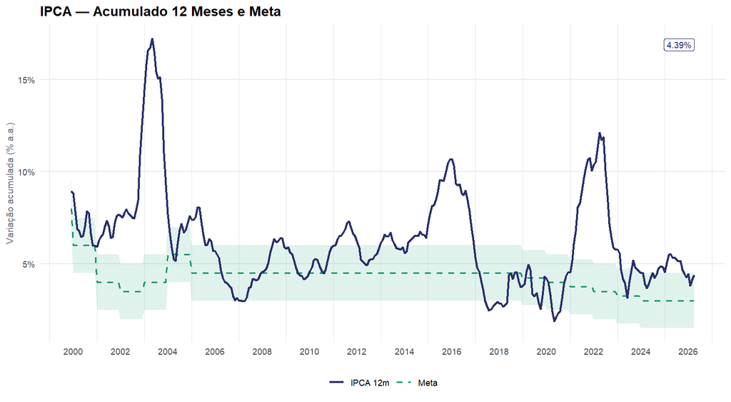

O IPCA acumulado em 12 meses é a medida de referência para o regime de metas de inflação adotado pelo Brasil. O Banco Central do Brasil opera o regime de metas definidas pelo Conselho Monetário Nacional, com meta central de 3.0% e intervalo de tolerância de ±1,5 ponto percentual. A faixa sombreada no gráfico delimita esse corredor: valores dentro da banda indicam cumprimento do objetivo de política monetária.

## Sazonalidade

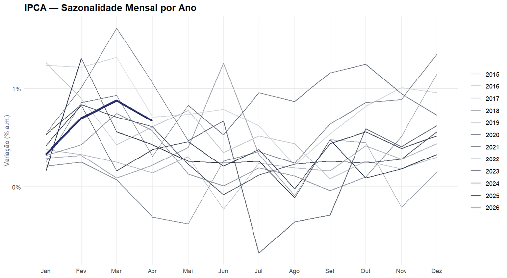

A linha em destaque representa o ano corrente. Sua comparação com os anos anteriores revela se a inflação de 2026 segue trajetória típica, mais benigna ou mais pressionada do que o histórico recente. Desvios significativos do padrão sazonal geralmente refletem choques específicos — climáticos, cambiais ou de política de preços — que merecem atenção analítica.

## Contribuições por Grupo

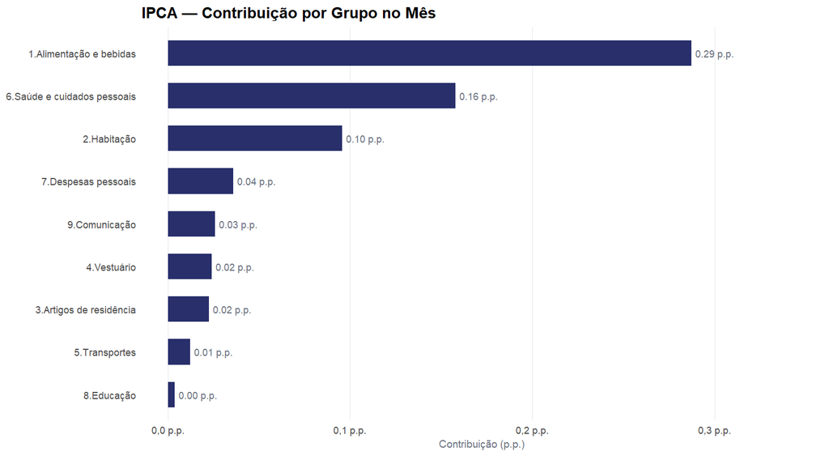

A decomposição do IPCA por grupos de despesa revela quais segmentos do orçamento familiar mais pressionaram (ou aliviaram) o índice em abril de 2026. A contribuição de cada grupo é calculada como o produto de sua variação mensal pelo respectivo peso na cesta de consumo, expresso em pontos percentuais (p.p.). A soma das nove contribuições deve reproduzir a variação total do IPCA no mês.

**Exibir código**

```r
contrib$mes_atual |>
  dplyr::select(grupo, variacao, peso, contribuicao) |>
  dplyr::arrange(dplyr::desc(contribuicao)) |>
  dplyr::mutate(
    variacao     = formatC(variacao,     digits = 2, format = "f"),
    peso         = formatC(peso,         digits = 2, format = "f"),
    contribuicao = formatC(contribuicao, digits = 2, format = "f")
  ) |>
  knitr::kable(
    col.names = c("Grupo", "Variação (%)", "Peso (%)", "Contribuição (p.p.)"),
    align     = c("l", "r", "r", "r")
  )
```

| Grupo | Variação (%) | Peso (%) | Contribuição (p.p.) |
| --- | --- | --- | --- |
| 1.Alimentação e bebidas | 1.34 | 21.45 | 0.29 |
| 6.Saúde e cuidados pessoais | 1.16 | 13.60 | 0.16 |
| 2.Habitação | 0.63 | 15.20 | 0.10 |
| 7.Despesas pessoais | 0.35 | 10.27 | 0.04 |
| 9.Comunicação | 0.57 | 4.52 | 0.03 |
| 4.Vestuário | 0.52 | 4.63 | 0.02 |
| 3.Artigos de residência | 0.65 | 3.47 | 0.02 |
| 5.Transportes | 0.06 | 20.61 | 0.01 |
| 8.Educação | 0.06 | 6.25 | 0.00 |

## Encerramento

O IPCA de abril de 2026 encerra o mês com variação de 0.67%, acumulando 2.60% no ano e 4.39% em 12 meses. A leitura conjunta das dimensões analisadas — variação mensal, acumulado frente à meta, padrão sazonal e decomposição por grupos — oferece uma visão abrangente da dinâmica inflacionária corrente.

Os dados utilizados neste relatório são de acesso público e atualizados automaticamente via APIs do Banco Central do Brasil (séries temporais 433 e 13521) e do IBGE (tabela 7060 do SIDRA). O relatório é gerado com Quarto e publicado via Posit Connect Cloud, garantindo reprodutibilidade e atualização mensal sem intervenção manual no código.

*Fontes: IBGE (IPCA — Tabela 7060/SIDRA); Banco Central do Brasil (séries 433 e 13521). Elaboração própria.*